# Historical Weather Modeling with XGBRegression

The goal of this project is to develop a weather model that uses independent variables—such as sunshine duration, daylight duration, precipitation sum, precipitation hours, month, and year—to predict the average temperature for a given day. The historical data for this project was sourced from https://open-meteo.com/ and pertains to Orem, Utah, spanning the years 2005 to 2025. At each step, I provide a summary of the objectives and explain how these contribute to building a robust and generally accurate weather model.

Importing the Necessary Libraries

```python
import pandas as pd
import numpy as np
import matplotlib.pyplot as plt
import matplotlib.patches as mpatches
import seaborn as sns
import warnings
warnings.filterwarnings('ignore')
```

# Exploratory Data Analysis

```python
path = '/content/OremUT_HistoricalWeather_2005-2025_OpenMeteo.csv'
data = pd.read_csv(path)
data = data.drop(len(data)-1)
data
```

|  | time | temperature_2m_max | temperature_2m_min | temperature_2m_mean | daylight_duration (h) | night_duration (h) | sunshine_duration (h) | precipitation_sum (mm) | precipitation_hours (h) |
| --- | --- | --- | --- | --- | --- | --- | --- | --- | --- |
| 0 | 1-Jan-2005 | 32.7 | 24.1 | 29.4 | 9.36 | 14.64 | 8.33 | 2.9 | 3.0 |
| 1 | 2-Jan-2005 | 37.4 | 19.5 | 27.3 | 9.38 | 14.62 | 3.87 | 0.0 | 0.0 |
| 2 | 3-Jan-2005 | 40.2 | 22.7 | 29.8 | 9.39 | 14.61 | 7.95 | 0.3 | 2.0 |
| 3 | 4-Jan-2005 | 40.0 | 27.2 | 32.2 | 9.41 | 14.59 | 8.38 | 4.9 | 18.0 |
| 4 | 5-Jan-2005 | 31.2 | 27.1 | 28.8 | 9.42 | 14.58 | 2.34 | 13.5 | 20.0 |
| ... | ... | ... | ... | ... | ... | ... | ... | ... | ... |
| 7300 | 27-Dec-2024 | 39.8 | 30.2 | 34.7 | 9.32 | 14.68 | 0.00 | 8.8 | 15.0 |
| 7301 | 28-Dec-2024 | 43.6 | 33.7 | 39.5 | 9.32 | 14.68 | 0.03 | 10.0 | 17.0 |
| 7302 | 29-Dec-2024 | 50.1 | 34.9 | 43.3 | 9.33 | 14.67 | 6.76 | 5.5 | 8.0 |
| 7303 | 30-Dec-2024 | 33.8 | 15.1 | 26.4 | 9.34 | 14.66 | 7.31 | 0.3 | 3.0 |
| 7304 | 31-Dec-2024 | 28.4 | 13.7 | 21.5 | 9.35 | 14.65 | 8.32 | 0.0 | 0.0 |

7305 rows × 9 columns

Below, I separate the time fields into month and year. This step will be useful for creating data visualizations. When building our models, we will also utilize the feature_importances_ function to evaluate the significance of the independent features (daylight_duration, night_duration, sunshine_duration, precipitation_sum, precipitation_hours) as well as month and year.

When feeding our data into the model, I will exclude the temperature_2m_min and temperature_2m_max columns. The goal of this project is to develop a model that uses independent variables to predict a dependent variable, temperature_2m_mean. Since temperature_2m_min and temperature_2m_max are not independent of temperature_2m_mean, they will be excluded from our set of independent variables.

```python
data['time'] = pd.to_datetime(data['time'])
data['year'] = data['time'].dt.strftime('%Y')
data['month'] = data['time'].dt.strftime('%m')
data['year'] = data['year'].astype(int)
data
```

|  | time | temperature_2m_max | temperature_2m_min | temperature_2m_mean | daylight_duration (h) | night_duration (h) | sunshine_duration (h) | precipitation_sum (mm) | precipitation_hours (h) | year | month |
| --- | --- | --- | --- | --- | --- | --- | --- | --- | --- | --- | --- |
| 0 | 2005-01-01 | 32.7 | 24.1 | 29.4 | 9.36 | 14.64 | 8.33 | 2.9 | 3.0 | 2005 | 01 |
| 1 | 2005-01-02 | 37.4 | 19.5 | 27.3 | 9.38 | 14.62 | 3.87 | 0.0 | 0.0 | 2005 | 01 |
| 2 | 2005-01-03 | 40.2 | 22.7 | 29.8 | 9.39 | 14.61 | 7.95 | 0.3 | 2.0 | 2005 | 01 |
| 3 | 2005-01-04 | 40.0 | 27.2 | 32.2 | 9.41 | 14.59 | 8.38 | 4.9 | 18.0 | 2005 | 01 |
| 4 | 2005-01-05 | 31.2 | 27.1 | 28.8 | 9.42 | 14.58 | 2.34 | 13.5 | 20.0 | 2005 | 01 |
| ... | ... | ... | ... | ... | ... | ... | ... | ... | ... | ... | ... |
| 7300 | 2024-12-27 | 39.8 | 30.2 | 34.7 | 9.32 | 14.68 | 0.00 | 8.8 | 15.0 | 2024 | 12 |
| 7301 | 2024-12-28 | 43.6 | 33.7 | 39.5 | 9.32 | 14.68 | 0.03 | 10.0 | 17.0 | 2024 | 12 |
| 7302 | 2024-12-29 | 50.1 | 34.9 | 43.3 | 9.33 | 14.67 | 6.76 | 5.5 | 8.0 | 2024 | 12 |
| 7303 | 2024-12-30 | 33.8 | 15.1 | 26.4 | 9.34 | 14.66 | 7.31 | 0.3 | 3.0 | 2024 | 12 |
| 7304 | 2024-12-31 | 28.4 | 13.7 | 21.5 | 9.35 | 14.65 | 8.32 | 0.0 | 0.0 | 2024 | 12 |

7305 rows × 11 columns

```python
data.describe()
```

|  | time | temperature_2m_max | temperature_2m_min | temperature_2m_mean | daylight_duration (h) | night_duration (h) | sunshine_duration (h) | precipitation_sum (mm) | precipitation_hours (h) | year |
| --- | --- | --- | --- | --- | --- | --- | --- | --- | --- | --- |
| count | 7305 | 7305.000000 | 7305.000000 | 7305.000000 | 7305.000000 | 7305.000000 | 7305.000000 | 7305.000000 | 7305.000000 | 7305.000000 |
| mean | 2015-01-01 00:00:00.000000256 | 59.375825 | 39.995537 | 50.250637 | 12.202910 | 11.797094 | 10.025517 | 1.339247 | 2.814511 | 2014.501027 |
| min | 2005-01-01 00:00:00 | 4.200000 | -12.700000 | -3.300000 | 9.290000 | 8.950000 | 0.000000 | 0.000000 | 0.000000 | 2005.000000 |
| 25% | 2010-01-01 00:00:00 | 41.300000 | 26.400000 | 34.000000 | 10.290000 | 9.870000 | 8.470000 | 0.000000 | 0.000000 | 2010.000000 |
| 50% | 2015-01-01 00:00:00 | 57.800000 | 38.700000 | 48.500000 | 12.230000 | 11.770000 | 10.520000 | 0.000000 | 0.000000 | 2015.000000 |
| 75% | 2020-01-01 00:00:00 | 79.100000 | 56.300000 | 68.800000 | 14.130000 | 13.710000 | 12.700000 | 0.800000 | 3.000000 | 2020.000000 |
| max | 2024-12-31 00:00:00 | 99.100000 | 78.600000 | 86.900000 | 15.050000 | 14.710000 | 14.040000 | 50.100000 | 24.000000 | 2024.000000 |
| std | NaN | 21.058306 | 18.322357 | 19.776111 | 1.978272 | 1.978276 | 3.214411 | 3.275793 | 5.110414 | 5.766735 |

```python
data.info(), data.shape
```

```
<class 'pandas.core.frame.DataFrame'>
RangeIndex: 7305 entries, 0 to 7304
Data columns (total 11 columns):
 #   Column                   Non-Null Count  Dtype
---  ------                   --------------  -----
 0   time                     7305 non-null   datetime64[ns]
 1   temperature_2m_max       7305 non-null   float64
 2   temperature_2m_min       7305 non-null   float64
 3   temperature_2m_mean      7305 non-null   float64
 4   daylight_duration (h)    7305 non-null   float64
 5   night_duration (h)       7305 non-null   float64
 6   sunshine_duration (h)    7305 non-null   float64
 7   precipitation_sum (mm)   7305 non-null   float64
 8   precipitation_hours (h)  7305 non-null   float64
 9   year                     7305 non-null   int64
 10  month                    7305 non-null   object
dtypes: datetime64[ns](1), float64(8), int64(1), object(1)
memory usage: 627.9+ KB
```

```
(None, (7305, 11))
```

```python
data.columns
```

```
Index(['time', 'temperature_2m_max', 'temperature_2m_min',
       'temperature_2m_mean', 'daylight_duration (h)', 'night_duration (h)',
       'sunshine_duration (h)', 'precipitation_sum (mm)',
       'precipitation_hours (h)', 'year', 'month'],
      dtype='object')
```

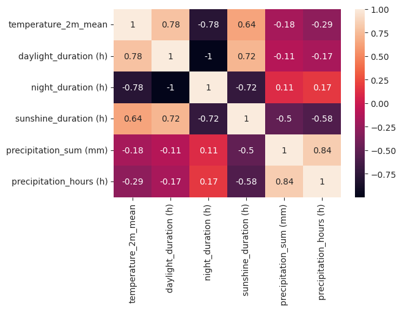

```python
correlationdata = data.drop(['time', 'year', 'temperature_2m_max', 'temperature_2m_min', 'month'], axis=1)
plt.figure(figsize=(6,4))
sns.heatmap(correlationdata.corr(), annot = True)
```

Above, we created a correlation matrix to examine the relationships between our variables and identify any high correlations that could impact our model. We define a high correlation as greater than 0.9 or less than -0.9. Upon inspection, we observe that daylight_duration and night_duration are perfectly negatively correlated, meaning these columns provide essentially the same information but with opposite effects. For example, while daylight_duration shows a strong positive correlation with mean temperature, night_duration exhibits an identical correlation but in a negative direction. In fact, the values in these columns are exact opposites. Therefore, to avoid redundancy, we will drop the night_duration column and retain daylight_duration during the pre-processing phase.

Additionally, we notice that precipitation_sum and precipitation_hours are highly positively correlated. This observation aligns with expectations, as longer durations of rainfall often result in higher precipitation totals. However, since these columns differ slightly, we will retain both to determine if one has a greater impact on our model than the other.

# Data Visualization

Below, we create a single plot containing five distinct diagrams for each 5-year period, highlighting the following:

1. Minimum, average, and maximum temperatures over the last 5 years.
2. Monthly distributions of minimum, maximum, and average temperature densities within the 5-year period.
3. Average day and night durations for each month over the past 5 years.
4. Average monthly precipitation during the last 5 years
5. Average monthly sunshine duration during the last 5 years

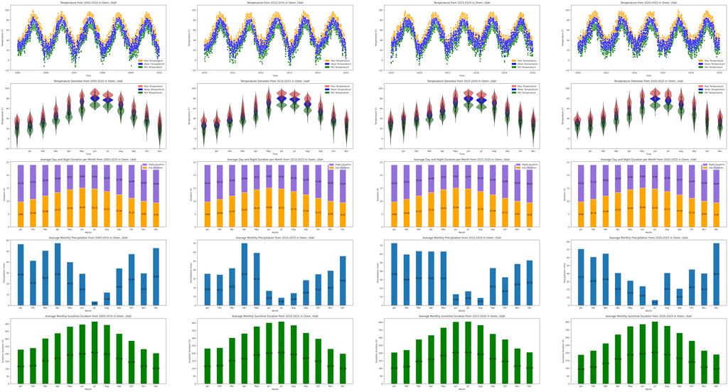

```python
fig, axes = plt.subplots(5, 4, figsize=(60,32))
sns.set_style("ticks")

def temp_plot(data, start_year, end_year, axes_index, axes_column):
  axes[axes_index, axes_column].set_ylabel("Temperature (F)")
  axes[axes_index, axes_column].set_xlabel("Time")
  axes[axes_index, axes_column].set_ylim(-20, 110)
  green_legend = mpatches.Patch(color = 'green',label='Min Temperature')
  orange_legend = mpatches.Patch(color='orange',label='Max Temperature')
  blue_legend = mpatches.Patch(color='blue',label='Mean Temperature')
  axes[axes_index, axes_column].legend(handles=[orange_legend, blue_legend, green_legend], loc='lower right')
  axes[axes_index, axes_column].set_title("Temperature from " + str(start_year) + "-" + str(end_year) + " in Orem, Utah")
  sns.scatterplot(data=data[(data['year'] >= start_year) & (data['year'] < end_year)], x='time', y='temperature_2m_min', ax=axes[axes_index, axes_column], color='green')
  sns.scatterplot(data=data[(data['year'] >= start_year) & (data['year'] < end_year)], x='time', y='temperature_2m_max', ax=axes[axes_index, axes_column], color='orange')
  sns.scatterplot(data=data[(data['year'] >= start_year) & (data['year'] < end_year)], x='time', y='temperature_2m_mean', ax=axes[axes_index, axes_column], color='blue')

def temp_density(data, start_year, end_year, axes_index, axes_column):
  axes[axes_index, axes_column].set_xlabel("Time")
  axes[axes_index, axes_column].set_ylabel("Temperature (F)")
  axes[axes_index, axes_column].set_ylim(-20, 110)
  axes[axes_index, axes_column].set_title("Temperature Densities from " + str(start_year) + "-" + str(end_year) + " in Orem, Utah")
  red_legend = mpatches.Patch(color='red', alpha=0.6, label='Max Temperature')
  blue_legend = mpatches.Patch(color='blue',label='Mean Temperature')
  green_legend = mpatches.Patch(color = 'green',label='Min Temperature')
  axes[axes_index, axes_column].legend(handles=[red_legend, blue_legend, green_legend])
  axes[axes_index, axes_column].set_xticks(range(1,13))
  axes[axes_index, axes_column].set_xticklabels(['Jan', 'Feb', 'Mar', 'Apr', 'May', 'Jun', 'Jul', 'Aug', 'Sep', 'Oct', 'Nov', 'Dec'])
  sns.violinplot(data=data[(data['year'] >= start_year) & (data['year'] < end_year)], x='month', y='temperature_2m_mean', ax=axes[axes_index, axes_column],color='blue')
  sns.violinplot(data=data[(data['year'] >= start_year) & (data['year'] < end_year)], x='month', y='temperature_2m_max', ax=axes[axes_index, axes_column], color = 'red', alpha=0.6)
  sns.violinplot(data=data[(data['year'] >= start_year) & (data['year'] < end_year)], x='month', y='temperature_2m_min', ax=axes[axes_index, axes_column], color='green', alpha=0.6)

def day_night_duration(data, start_year, end_year, axes_index, axes_column):
  filtered_data = data[(data['year'] >= start_year) & (data['year'] < end_year)]
  grouped_data = filtered_data.groupby(['month'])[['daylight_duration (h)', 'night_duration (h)']].mean().reset_index()
  dat_night = pd.melt(grouped_data, id_vars=['month'], value_vars=['daylight_duration (h)','night_duration (h)'], var_name='variable',value_name='Average')
  dat_night['month'] = dat_night['month'].astype(int)

  axes[axes_index, axes_column].bar(dat_night[dat_night['variable'] == 'daylight_duration (h)']['month'],
         dat_night[dat_night['variable'] == 'daylight_duration (h)']['Average'],
          label='Daylight', width=0.5, color="orange")
  axes[axes_index, axes_column].bar(dat_night[dat_night['variable'] == 'night_duration (h)']['month'],
         dat_night[dat_night['variable'] == 'night_duration (h)']['Average'],
          bottom=dat_night[dat_night['variable'] == 'daylight_duration (h)']['Average'],
         label='Night', width=0.5, color="mediumpurple")
  for container in axes[axes_index, axes_column].containers:
    axes[axes_index, axes_column].bar_label(container, label_type='center', color='black', fontsize=10, fmt='%.2f')

  axes[axes_index, axes_column].set_xlabel("Month")
  axes[axes_index, axes_column].set_ylabel("Duration (h)")
  axes[axes_index, axes_column].set_title("Average Day and Night Duration per Month from " + str(start_year) + "-" + str(end_year) + " in Orem, Utah")
  orange_legend = mpatches.Patch(color="orange", label="Day Duration")
  purple_legend = mpatches.Patch(color="mediumpurple", label="Night Duration")
  axes[axes_index, axes_column].legend(handles=[purple_legend, orange_legend])
  axes[axes_index, axes_column].set_xticks(range(1,13))
  axes[axes_index, axes_column].set_xticklabels(['Jan', 'Feb', 'Mar', 'Apr', 'May', 'Jun', 'Jul', 'Aug', 'Sep','Oct', 'Nov', 'Dec'])

def average_precipitation(data, start_year, end_year, axes_index, axes_column) :
  filtered_data = data[(data['year'] >= start_year) & (data['year'] < end_year)]
  grouped_data = filtered_data.groupby(['month', 'year'])[['precipitation_sum (mm)']].sum().reset_index()
  precip_data = grouped_data.groupby(['month'])[['precipitation_sum (mm)']].mean().reset_index()
  data_prec = pd.melt(precip_data, id_vars=['month'], value_vars=['precipitation_sum (mm)'], var_name='variable',value_name='Average')
  data_prec['month'] = data_prec['month'].astype(int)

  bar_plot = axes[axes_index, axes_column].bar(data_prec[data_prec['variable'] == 'precipitation_sum (mm)']['month'],
          data_prec[data_prec['variable'] == 'precipitation_sum (mm)']['Average'], width =0.5)
  axes[axes_index, axes_column].bar_label(bar_plot, label_type='center', color='black', fontsize=10, fmt='%.2f')
  axes[axes_index, axes_column].set_xticks(range(1,13))
  axes[axes_index, axes_column].set_xticklabels(['Jan', 'Feb', 'Mar', 'Apr', 'May', 'Jun', 'Jul', 'Aug', 'Sep', 'Oct', 'Nov', 'Dec'])
  axes[axes_index, axes_column].set_xlabel("Month")
  axes[axes_index, axes_column].set_ylabel("Precipitation (mm)")
  axes[axes_index, axes_column].set_title("Average Monthly Precipitation from " + str(start_year) + "-" + str(end_year) + " in Orem, Utah")

def average_sunshine(data, start_year, end_year, axes_index, axes_column):
  filtered_data = data[(data['year'] >= start_year) & (data['year'] < end_year)]
  grouped_data = filtered_data.groupby(['month', 'year'])[['sunshine_duration (h)']].sum().reset_index()
  precip_data = grouped_data.groupby(['month'])[['sunshine_duration (h)']].mean().reset_index()
  data_prec = pd.melt(precip_data, id_vars=['month'], value_vars=['sunshine_duration (h)'], var_name='variable',value_name='Average')
  data_prec['month'] = data_prec['month'].astype(int)

  bar_plot = axes[axes_index, axes_column].bar(data_prec[data_prec['variable'] == 'sunshine_duration (h)']['month'],
          data_prec[data_prec['variable'] == 'sunshine_duration (h)']['Average'], width =0.5, color = 'green')
  axes[axes_index, axes_column].bar_label(bar_plot, label_type='center', color='black', fontsize=10, fmt='%.2f')
  axes[axes_index, axes_column].set_xticks(range(1,13))
  axes[axes_index, axes_column].set_xticklabels(['Jan', 'Feb', 'Mar', 'Apr', 'May', 'Jun', 'Jul', 'Aug', 'Sep', 'Oct', 'Nov', 'Dec'])
  axes[axes_index, axes_column].set_xlabel("Month")
  axes[axes_index, axes_column].set_ylabel("Sunshine Duration (h)")
  axes[axes_index, axes_column].set_title("Average Monthly Sunshine Duration from " + str(start_year) + "-" + str(end_year) + " in Orem, Utah")



# Plots for 2005-2009
temp_plot(data, 2005, 2010, 0, 0)
temp_density(data, 2005, 2010, 1, 0)
day_night_duration(data, 2005, 2010, 2, 0)
average_precipitation(data, 2005, 2010, 3, 0)
average_sunshine(data, 2005, 2010, 4, 0)

# Plots for 2010-2014
temp_plot(data, 2010, 2015, 0, 1)
temp_density(data, 2010, 2015, 1, 1)
day_night_duration(data, 2010, 2015, 2, 1)
average_precipitation(data, 2010, 2015, 3, 1)
average_sunshine(data, 2010, 2015, 4, 1)

# Plots for 2015-2019
temp_plot(data, 2015, 2020, 0, 2)
temp_density(data, 2015, 2020, 1, 2)
day_night_duration(data, 2015, 2020, 2, 2)
average_precipitation(data, 2015, 2020, 3, 2)
average_sunshine(data, 2015, 2020, 4, 2)

# Plots for 2020-2024
temp_plot(data, 2020, 2025, 0 ,3)
temp_density(data, 2020, 2025, 1, 3)
day_night_duration(data, 2020, 2025, 2, 3)
average_precipitation(data, 2020, 2025, 3, 3)
average_sunshine(data, 2020, 2025, 4, 3)
```

In the diagram above, I present five distinct plots for each 5-year period.

- The first row of plots displays the maximum, average, and minimum temperatures over time. A quick glance reveals that minimum temperatures have increased, indicating that winter months are generally becoming warmer as time goes on.
- The second row depicts temperature densities by month for each 5-year period. Similarly, this row suggests winter months are increasing in temperature over time. Additionally, summer months exhibit less variation in temperatures, while the rest of the year shows wider ranges in maximum, average, and minimum temperatures.
- The third row highlights the average day and night durations by month across each 5-year period. This row suggests that day and night durations remain largely consistent over the years.
- The fourth row illustrates the average monthly precipitation sum (mm). As expected, winter months generally experience higher precipitation levels than summer months. Notably, July or August consistently shows the lowest average precipitation sum for each 5-year period.
- The final row showcases the average monthly sunshine duration across each 5-year period, which remains mostly consistent throughout the years.

# Data Pre-Processing and Standardization

In this section, we will pre-process our data. Using the describe function below, we observe that there are no missing values, which is ideal. As discussed earlier, we will drop the night_duration column. We will also encode the categorical data and standardize the numerical data. This is necessary because we do not want the year column (ranging from 2005 to 2025) to outweigh other columns such as sunshine_duration or precipitation_sum. While sunshine_duration has a greater impact on temperature than the year column, failing to standardize the data could cause our model to assign excessive weight to the year column. This would reduce the accuracy of our model, so it is crucial to standardize and encode the data properly before feeding it into the model.

```python
data = data.drop(['night_duration (h)', 'temperature_2m_max', 'temperature_2m_min'], axis=1)
data
```

|  | time | temperature_2m_mean | daylight_duration (h) | sunshine_duration (h) | precipitation_sum (mm) | precipitation_hours (h) | year | month |
| --- | --- | --- | --- | --- | --- | --- | --- | --- |
| 0 | 2005-01-01 | 29.4 | 9.36 | 8.33 | 2.9 | 3.0 | 2005 | 01 |
| 1 | 2005-01-02 | 27.3 | 9.38 | 3.87 | 0.0 | 0.0 | 2005 | 01 |
| 2 | 2005-01-03 | 29.8 | 9.39 | 7.95 | 0.3 | 2.0 | 2005 | 01 |
| 3 | 2005-01-04 | 32.2 | 9.41 | 8.38 | 4.9 | 18.0 | 2005 | 01 |
| 4 | 2005-01-05 | 28.8 | 9.42 | 2.34 | 13.5 | 20.0 | 2005 | 01 |
| ... | ... | ... | ... | ... | ... | ... | ... | ... |
| 7300 | 2024-12-27 | 34.7 | 9.32 | 0.00 | 8.8 | 15.0 | 2024 | 12 |
| 7301 | 2024-12-28 | 39.5 | 9.32 | 0.03 | 10.0 | 17.0 | 2024 | 12 |
| 7302 | 2024-12-29 | 43.3 | 9.33 | 6.76 | 5.5 | 8.0 | 2024 | 12 |
| 7303 | 2024-12-30 | 26.4 | 9.34 | 7.31 | 0.3 | 3.0 | 2024 | 12 |
| 7304 | 2024-12-31 | 21.5 | 9.35 | 8.32 | 0.0 | 0.0 | 2024 | 12 |

7305 rows × 8 columns

Below, we utilize the LabelEncoder function to transform the categorical columns, month and year, into numerical expressions.

```python
from sklearn.preprocessing import LabelEncoder
label_month = LabelEncoder()
label_year = LabelEncoder()
data['month'] = label_month.fit_transform(data['month'])
data['year'] = label_year.fit_transform(data['year'])
data
```

|  | time | temperature_2m_mean | daylight_duration (h) | sunshine_duration (h) | precipitation_sum (mm) | precipitation_hours (h) | year | month |
| --- | --- | --- | --- | --- | --- | --- | --- | --- |
| 0 | 2005-01-01 | 29.4 | 9.36 | 8.33 | 2.9 | 3.0 | 0 | 0 |
| 1 | 2005-01-02 | 27.3 | 9.38 | 3.87 | 0.0 | 0.0 | 0 | 0 |
| 2 | 2005-01-03 | 29.8 | 9.39 | 7.95 | 0.3 | 2.0 | 0 | 0 |
| 3 | 2005-01-04 | 32.2 | 9.41 | 8.38 | 4.9 | 18.0 | 0 | 0 |
| 4 | 2005-01-05 | 28.8 | 9.42 | 2.34 | 13.5 | 20.0 | 0 | 0 |
| ... | ... | ... | ... | ... | ... | ... | ... | ... |
| 7300 | 2024-12-27 | 34.7 | 9.32 | 0.00 | 8.8 | 15.0 | 19 | 11 |
| 7301 | 2024-12-28 | 39.5 | 9.32 | 0.03 | 10.0 | 17.0 | 19 | 11 |
| 7302 | 2024-12-29 | 43.3 | 9.33 | 6.76 | 5.5 | 8.0 | 19 | 11 |
| 7303 | 2024-12-30 | 26.4 | 9.34 | 7.31 | 0.3 | 3.0 | 19 | 11 |
| 7304 | 2024-12-31 | 21.5 | 9.35 | 8.32 | 0.0 | 0.0 | 19 | 11 |

7305 rows × 8 columns

Below, we use the StandardScaler function from the sklearn library to standardize the temperature_2m_mean, daylight_duration, sunshine_duration, precipitation_sum and precipitation_hours columns. Afterward, we concatenate the encoded month and year columns with our standardized dataset. Finally, we proceed to create our training and testing datasets.

```python
from sklearn.preprocessing import StandardScaler
scaler = StandardScaler()
standardized_data = scaler.fit_transform(data[['temperature_2m_mean', 'daylight_duration (h)', 'sunshine_duration (h)', 'precipitation_sum (mm)', 'precipitation_hours (h)']])
standardized_data = pd.DataFrame(standardized_data, columns=['temperature_2m_mean', 'daylight_duration (h)', 'sunshine_duration (h)', 'precipitation_sum (mm)', 'precipitation_hours (h)'])
standardized = pd.concat([standardized_data, data[['month', 'year']]], axis=1)
standardized['time'] = data['time']
standardized
```

|  | temperature_2m_mean | daylight_duration (h) | sunshine_duration (h) | precipitation_sum (mm) | precipitation_hours (h) | month | year | time |
| --- | --- | --- | --- | --- | --- | --- | --- | --- |
| 0 | -1.054407 | -1.437166 | -0.527510 | 0.476483 | 0.036299 | 0 | 0 | 2005-01-01 |
| 1 | -1.160603 | -1.427055 | -1.915106 | -0.408859 | -0.550778 | 0 | 0 | 2005-01-02 |
| 2 | -1.034179 | -1.422000 | -0.645735 | -0.317272 | -0.159393 | 0 | 0 | 2005-01-03 |
| 3 | -0.912812 | -1.411889 | -0.511954 | 1.087064 | 2.971683 | 0 | 0 | 2005-01-04 |
| 4 | -1.084748 | -1.406834 | -2.391120 | 3.712562 | 3.363067 | 0 | 0 | 2005-01-05 |
| ... | ... | ... | ... | ... | ... | ... | ... | ... |
| 7300 | -0.786388 | -1.457387 | -3.119142 | 2.277697 | 2.384606 | 11 | 19 | 2024-12-27 |
| 7301 | -0.543655 | -1.457387 | -3.109808 | 2.644045 | 2.775991 | 11 | 19 | 2024-12-28 |
| 7302 | -0.351490 | -1.452332 | -1.015968 | 1.270238 | 1.014760 | 11 | 19 | 2024-12-29 |
| 7303 | -1.206115 | -1.447276 | -0.844852 | -0.317272 | 0.036299 | 11 | 19 | 2024-12-30 |
| 7304 | -1.453906 | -1.442221 | -0.530621 | -0.408859 | -0.550778 | 11 | 19 | 2024-12-31 |

7305 rows × 8 columns

# Creating the Train, Validation and Test Data Sets

Below, we construct training, testing, and validation datasets to evaluate our model's performance. The training dataset will be used to train the model, while the validation dataset will assess how the model responds to unseen data. Finally, we will input the testing dataset to measure how accurately the model predicts temperature_2m_mean values. In the following sections, we will create several diagrams to visualize and showcase the model's accuracy.

```python
from sklearn.utils import shuffle

# Creating the Train, Validation and Test Data Sets
train_set = standardized[standardized['year'] < 15]
val_set = standardized[(standardized['year'] >= 15) & (standardized['year'] < 17)]
test_set = standardized[(standardized['year'] >= 17)]

# Splitting up the Train Data Set
x_train_set = train_set.drop(['temperature_2m_mean', 'time'], axis=1)
y_train_set = train_set['temperature_2m_mean']

# Splitting up the Validation Data Set
x_val_set = val_set.drop(['temperature_2m_mean', 'time'], axis=1)
y_val_set = val_set['temperature_2m_mean']

# Splitting up the Test Data Set
x_test_set = test_set.drop(['temperature_2m_mean', 'time'], axis=1)
y_test_set = test_set['temperature_2m_mean']

x_train_set
```

|  | daylight_duration (h) | sunshine_duration (h) | precipitation_sum (mm) | precipitation_hours (h) | month | year |
| --- | --- | --- | --- | --- | --- | --- |
| 0 | -1.437166 | -0.527510 | 0.476483 | 0.036299 | 0 | 0 |
| 1 | -1.427055 | -1.915106 | -0.408859 | -0.550778 | 0 | 0 |
| 2 | -1.422000 | -0.645735 | -0.317272 | -0.159393 | 0 | 0 |
| 3 | -1.411889 | -0.511954 | 1.087064 | 2.971683 | 0 | 0 |
| 4 | -1.406834 | -2.391120 | 3.712562 | 3.363067 | 0 | 0 |
| ... | ... | ... | ... | ... | ... | ... |
| 5473 | -1.462442 | -0.648847 | -0.408859 | -0.550778 | 11 | 14 |
| 5474 | -1.457387 | -0.580400 | -0.286743 | 0.231991 | 11 | 14 |
| 5475 | -1.452332 | -2.039554 | -0.317272 | 0.036299 | 11 | 14 |
| 5476 | -1.452332 | -1.423536 | -0.256214 | 0.427683 | 11 | 14 |
| 5477 | -1.447276 | -0.720404 | -0.408859 | -0.550778 | 11 | 14 |

5478 rows × 6 columns

```python
x_train_set.shape, y_train_set.shape, x_val_set.shape, y_val_set.shape, x_test_set.shape, y_test_set.shape
```

```
((5478, 6), (5478,), (731, 6), (731,), (1096, 6), (1096,))
```

# XGBRegression Model

Below, we import the XGBRegression model and fit it to our training data. We set n_estimators to 5,000, learning_rate to 0.001, and early_stopping_rounds to 50. This configuration instructs the model to build up to 5,000 base regression models while using the root mean square error (RMSE) to evaluate the performance of each model. The early_stopping_rounds parameter halts the training process if the model's performance on the validation set does not improve after 50 consecutive rounds.

```python
# Importing XGRegression model
import xgboost as xgb
from xgboost import XGBRegressor
from xgboost import plot_importance
from sklearn.metrics import mean_squared_error

regression = xgb.XGBRegressor(n_estimators=5000, learning_rate = 0.001,
                              early_stopping_rounds = 50)
regression.fit(x_train_set, y_train_set, eval_set = [(x_train_set, y_train_set), (x_val_set, y_val_set)],
               verbose = 100)
```

```
XGBRegressor(base_score=None, booster=None, callbacks=None,
             colsample_bylevel=None, colsample_bynode=None,
             colsample_bytree=None, device=None, early_stopping_rounds=50,
             enable_categorical=False, eval_metric=None, feature_types=None,
             gamma=None, grow_policy=None, importance_type=None,
             interaction_constraints=None, learning_rate=0.001, max_bin=None,
             max_cat_threshold=None, max_cat_to_onehot=None,
             max_delta_step=None, max_depth=None, max_leaves=None,
             min_child_weight=None, missing=nan, monotone_constraints=None,
             multi_strategy=None, n_estimators=5000, n_jobs=None,
             num_parallel_tree=None, random_state=None, ...)
```

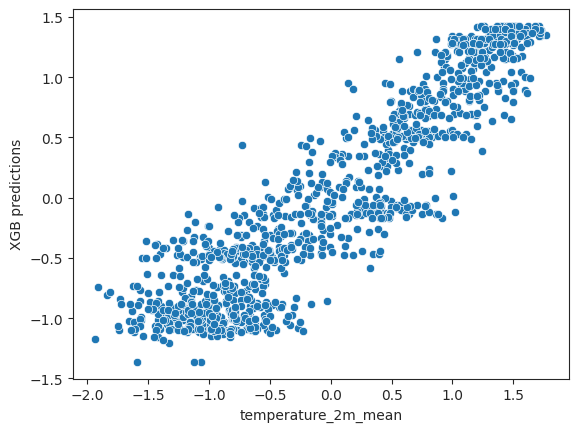

```python
xgb_predictions = regression.predict(x_test_set)

y_test_set = pd.DataFrame(y_test_set, columns=['temperature_2m_mean'])
y_test_set['XGB predictions'] = xgb_predictions

sns.scatterplot(data=y_test_set, x='temperature_2m_mean', y='XGB predictions')
```

In the diagram above, we plot temperature_2m_mean against the predicted temperature_2m_mean generated by our XGBRegression model. Ideally, the points would align perfectly along the y = x line, indicating that the model has accurately predicted the temperature_2m_mean values. However, as shown in the graph, deviations from this line reveal instances where the model either underestimates or overestimates the temperature_2m_mean values.

Despite these deviations, the graph generally follows the y = x trend line, suggesting that the model performs reasonably well in predicting temperature_2m_mean. Notably, there is greater dispersion around the y = x line in the lower-left corner compared to the upper-right corner. This indicates that the model struggles more with predicting lower temperatures (negative numbers) than higher temperatures (positive numbers).

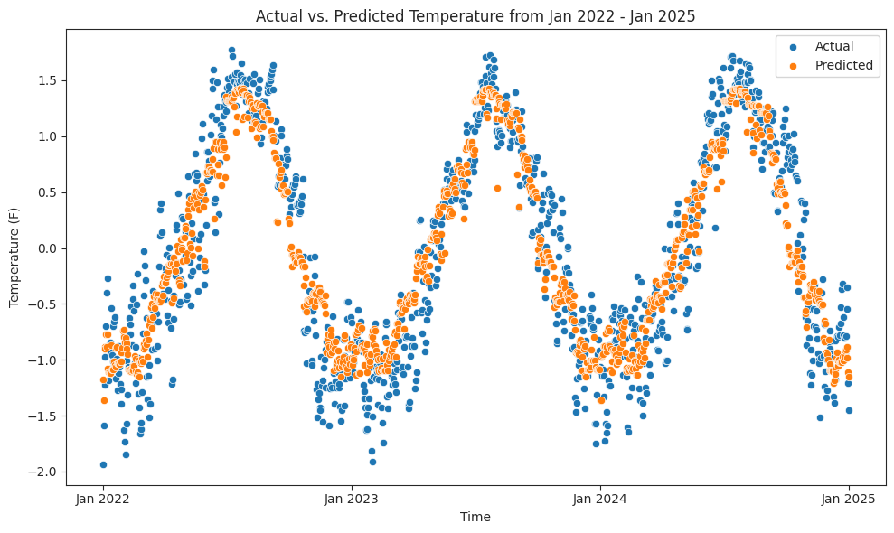

```python
fig = plt.figure(figsize=(10,6))

test_set['XGB predictions'] = xgb_predictions
test_set = test_set.sort_values(by=['time'])
test_set
sns.scatterplot(data=test_set, x='time', y='temperature_2m_mean', label='Actual')
sns.scatterplot(data=test_set, x='time', y='XGB predictions', label='Predicted')

plt.xticks(test_set['time'][::365], ['Jan 2022', 'Jan 2023', 'Jan 2024', 'Jan 2025'])
plt.title('Actual vs. Predicted Temperature from Jan 2022 - Jan 2025')
plt.xlabel('Time')
plt.ylabel('Temperature (F)')
plt.tight_layout()
```

In the diagram above, we plot the actual temperature_2m_mean and the predicted temperature_2m_mean over time. It is evident that our model struggles more with accurately predicting lower temperature values (negative numbers) compared to higher temperature values (positive numbers). Nevertheless, there is noticeable dispersion at both extremes.

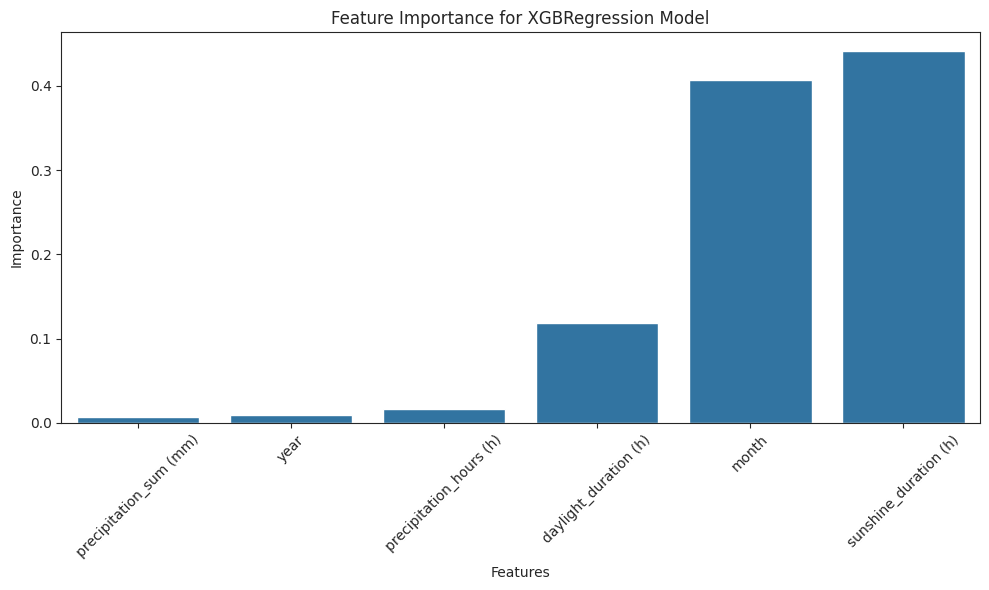

```python
xgb_regression_importances = regression.feature_importances_
xgb_reg_feature_importances = pd.DataFrame({'Feature': x_train_set.columns, 'Importance' : xgb_regression_importances})
xgb_reg_feature_importances = xgb_reg_feature_importances.sort_values(by='Importance')
plt.figure(figsize=(10,6))
sns.barplot(data=xgb_reg_feature_importances, x='Feature', y='Importance')
plt.title('Feature Importance for XGBRegression Model')
plt.xlabel('Features')
plt.ylabel('Importance')
plt.xticks(rotation=45)
plt.tight_layout()
```

Above, we plot the feature_importances_ for our XGBRegression model. Clearly, our regression model weights sunshine_duration (h), month and daylight_duration (h) more than precipitation_hours (h), year or precipitation_sum (mm). This makes sense, as weather would be dependent on the month of the year, the sunshine_duration and daylight_duration of each day/month throughout that year. This diagram is also saying that precipitation_sum, precipitation_hours and year are not weighted heavily when predicting what the temperature_2m_mean is on a given day.

# Conclusion

After extensive exploratory data analysis, pre-processing, and standardization, we successfully developed a weather model that takes in variables such as precipitation_sum (mm), precipitation_hours (h), daylight_duration (h), sunshine_duration (h), month, and year to predict the average temperature for a given day. While the model is not without its flaws, it effectively captures the seasonality present in the dataset and can generally predict the weather for a specific day. Weather forecasting is inherently complex, but by leveraging historical data, we gain valuable insights into how each independent variable influences the predicted average temperature.